# Streamlitを用いた音響信号処理ダッシュボードの開発(Tokyo BISH Bash #03発表資料)

## 自己紹介およびPyData Osakaの紹介

- 別スライドで説明します

## 本日の概要

- Streamlitの紹介
- 実例を踏まえた使用方法の紹介
- Herokuへのデプロイ方法の紹介
- その他

## 本日の資料

- https://www.hiromasa.info/posts/22/

[figure not shown]

## Streamlitとは

- Webブラウザで動作するダッシュボードを作成するためのライブラリ
  - 複数のコンポーネントが連携して動作するもの
- Pythonのみで記述が可能
  - `plotly/dash`と比較されることが多い

### どんな場面で必要か

- 実装したアルゴリズムを他者に試してもらいたい
  - Webフロントエンドがあると便利
- パラメータ変更による試行錯誤が必要な場面
  - 調整ツールとして使用

### 実例

- 今回作成したダッシュボードを簡単に紹介

### GitHub Star History

- https://star-history.t9t.io/#streamlit/streamlit&plotly/dash

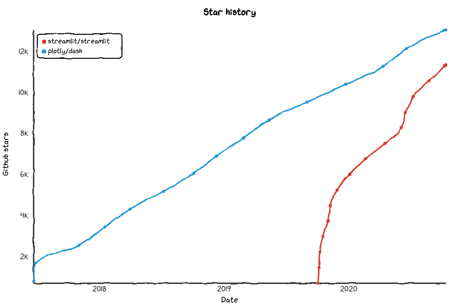

### Dashとの違い

- [Towards Data Scienceの記事](https://towardsdatascience.com/plotly-dash-vs-streamlit-which-is-the-best-library-for-building-data-dashboard-web-apps-97d7c98b938c)
  - Dash
    - プロダクション/エンタープライズ環境での実行に主眼
  - Streamlit
    - ラピッドプロトタイピングに主眼
- [plotly.comの比較記事](https://plotly.com/comparing-dash-shiny-streamlit/)
  - Rのshinyも含めて比較

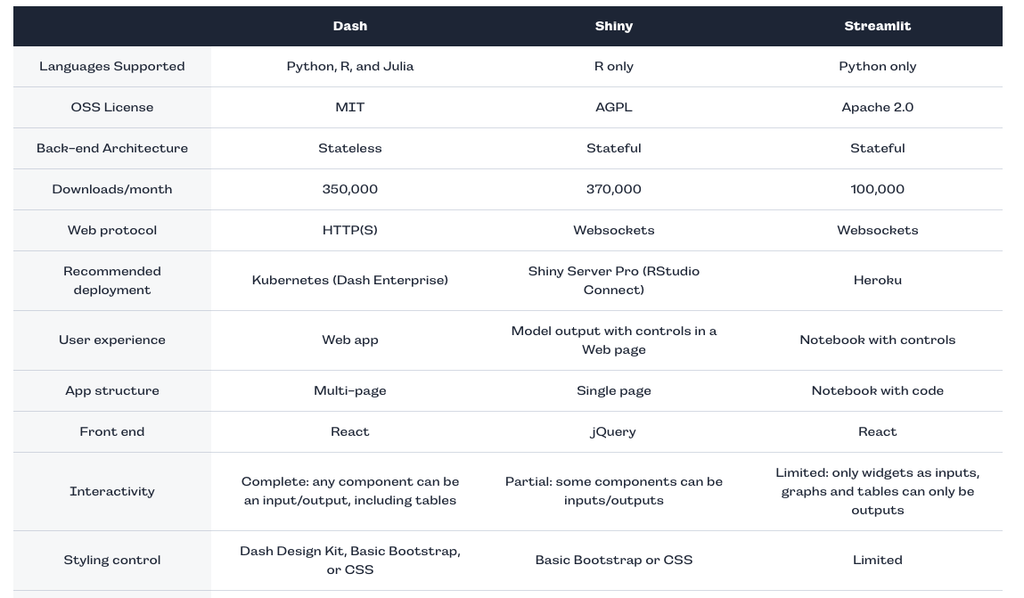

### Streamlitの魅力

- 手軽にフロントエンドが構築可能
  - `javascript`不要、スクリプトライクな記述
  - 各種pythonライブラリにGUIを付与
- 豊富な描画ライブラリ
  - `matplotlib`, `plotly`, `altair`, ...
  - Dashはplotlyを前提

### Streamlitの情報

- [公式ドキュメント](https://docs.streamlit.io/en/stable/index.html)
- [コミュニティフォーラム](https://discuss.streamlit.io/)

## 本発表におけるバージョン

- 0.68.0
  - [10/8にリリースされたばかり](https://docs.streamlit.io/en/stable/changelog.html)
  - 1月あたり1〜2回マイナーバージョンが更新
    - まだ不安定

## 基本機能の紹介

### 導入方法

- `pip install streamlit`

### 実行方法

```python
%%writefile app.py
import streamlit as st

st.write("# Hello, Streamlit!")
```

```
Overwriting app.py
```

```python
!streamlit run app.py
```

```
  You can now view your Streamlit app in your browser.

  Network URL: http://172.17.0.2:8501
  External URL: http://49.251.189.62:8501

^C
  Stopping...
```

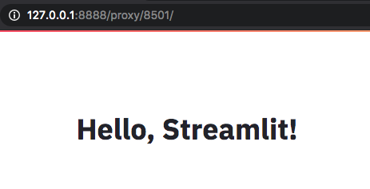

- ノートブックが固まるため以降はターミナル上から`streamlit`コマンドを実行

### アプリ更新時の反映が容易

- ファイルの上書きを検知し`Rerun`ボタンを自動表示

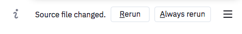

```python
%%writefile app.py
import streamlit as st

st.write("# Hello, Streamlit!")
st.write("# Where is Rerun button?")
```

```
Overwriting app.py
```

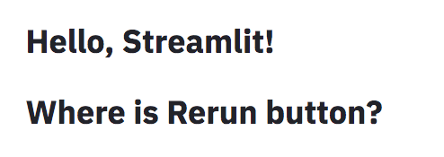

### スクリプトエラーもブラウザ上に表示

- デバッグも容易

```python
%%writefile app.py
import streamlit as st

st.write("# Hello, Streamlit!")
raise ValueError
```

```
Overwriting app.py
```

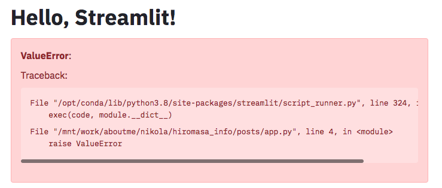

### `st.write`

- 引数に与えたオブジェクトを画面に表示
- markdownはHTMLに変換して表示
- listやdictは階層表示
- ndarrayやpandasのDataFrameはテーブルとして表示

```python
%%writefile app.py
import numpy as np
import pandas as pd
import streamlit as st

st.write([1, 2, 3])
st.write({"hello": "world!"})
st.write(np.arange(10).reshape(1,10))
st.write(pd.DataFrame(np.random.randn(10, 4), columns=["1", "2", "3", "4"]))
```

```
Overwriting app.py
```

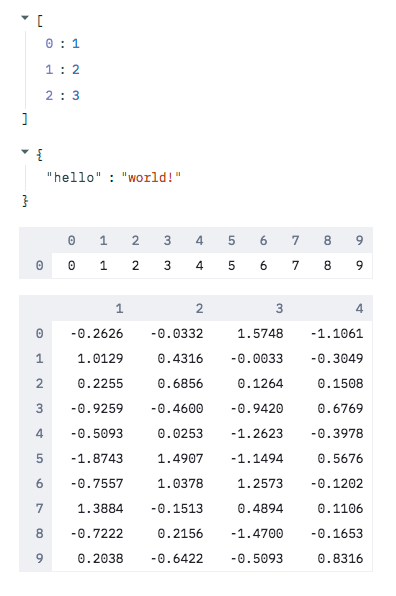

## 本日紹介するダッシュボード

- https://github.com/wrist/streamlit-dsp
  - 窓関数ビューワ
  - デジタルフィルタデザイナ
  - pyroomacousticsを用いたシミュレータ
  - espnet2のフロントエンド

### ブランチ

- `master`
- `st_v066`
  - `Steramlit`のバージョンを0.66.0にしたもの
- `heroku`
  - Herokuへのアップロードに必要なファイルを格納
- `espnet2`
  - 3.6.x系で動作させるため別ブランチ

### github上のstreamlitアプリ

- 一般的には直接実行可能
  - `streamlit run https://github.com/user/repos.git`
- 今回のアプリはimportの都合でエラーが生じる

## 窓関数ビューワの構築

- `scipy.signal`を使用
- `Streamlit`によるアプリ構築をライブコーディング的に実施
- 現状のダッシュボード
  - [window_viwer.py](https://github.com/wrist/streamlit-dsp/blob/master/streamlit_dsp/window_viewer.py)

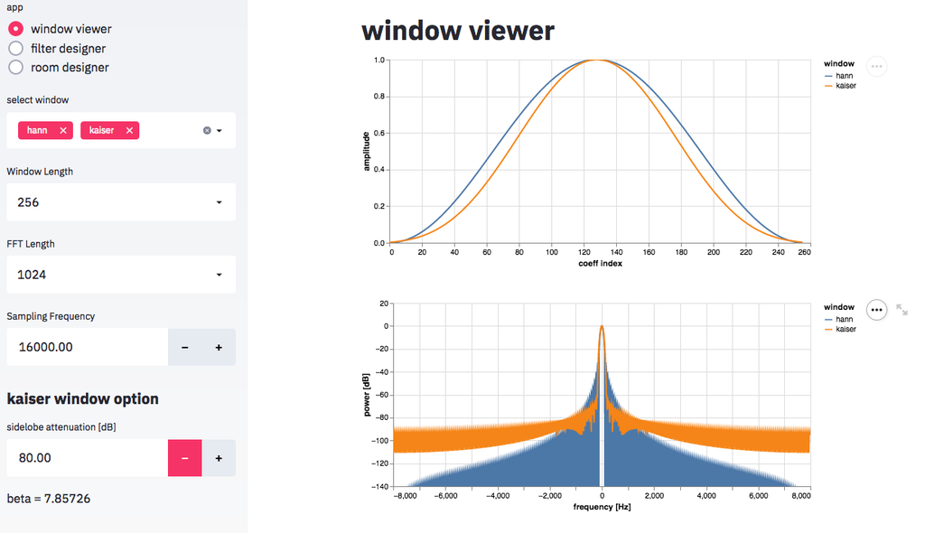

### 窓関数の選択インタフェース

- サイドバーに`selectbox`で表示
- サイドバー上への配置
  - `st.sidebar.xxx`
  - `st.xxx`と本体に配置できるウィジェットは何でも配置可能

### `st.selectbox`

`st.selectbox(ラベル名, 選択肢のリスト, デフォルト項目のインデックス)`

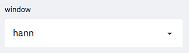

```python
%%writefile app.py
import streamlit as st

windows = ["boxcar", "triang", "blackman", "hamming", "hann", "bartlett", "flattop",
           "parzen", "bohman", "blackmanharris", "nuttall", "barthann"]
```

```
Overwriting app.py
```

- `%%writefile -a app.py`で`app.py`に追記

```python
%%writefile -a app.py

win_name = st.sidebar.selectbox("window", windows, 4)
st.write(win_name)
```

```
Appending to app.py
```

- この時点の見た目

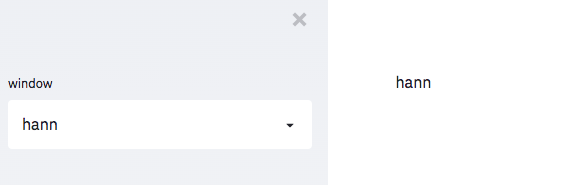

### 窓関数の窓長およびFFT長の取得

- 同様に`st.selectbox`で2の累乗の値を取得

```python
%%writefile -a app.py
two_powers = [2**i for i in range(16)]
Nx = st.sidebar.selectbox("Window Length", two_powers, 8)
nfft = st.sidebar.selectbox("FFT Length", two_powers, 10)

st.write(win_name, Nx, nfft)
```

```
Appending to app.py
```

- この時点での見た目

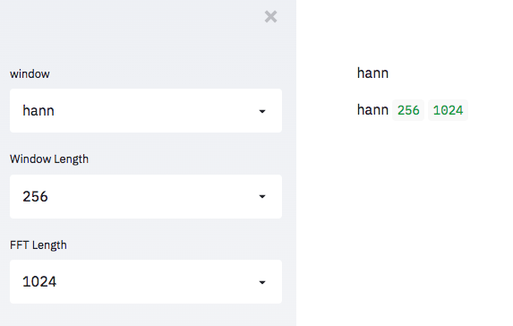

### 窓関数の取得および描画

- 窓関数の取得
  - `scipy.signal.get_window`
  - `scipy.fft.fft`で周波数分析
- 描画
  - matplotlibをひとまず使用
- 必要なライブラリをimport

```python
%%writefile -a app.py
import matplotlib.pyplot as plt
import numpy as np
import scipy.signal as sg
import scipy.fft as fft
```

```
Appending to app.py
```

- 窓関数を取得し周波数特性を計算

```python
%%writefile -a app.py
eps = 1.e-12
win = sg.get_window(win_name, Nx)
W = 20.0 * np.log10(np.abs(fft.fft(win, nfft)) + eps)
W = fft.fftshift(W)
```

```
Appending to app.py
```

- `matplotlib`を用いて描画

```python
%%writefile -a app.py
fig, axes = plt.subplots(2, 1)
axes[0].plot(win)
axes[1].plot(W)
st.pyplot(fig)
```

```
Appending to app.py
```

### `st.pyplot`

- `matplotlib`のfigureを描画
  - `st.pyplot(fig)`
- 使い慣れたmatplotlibを使える
  - が、javascriptの恩恵が得られない
- この時点での見た目

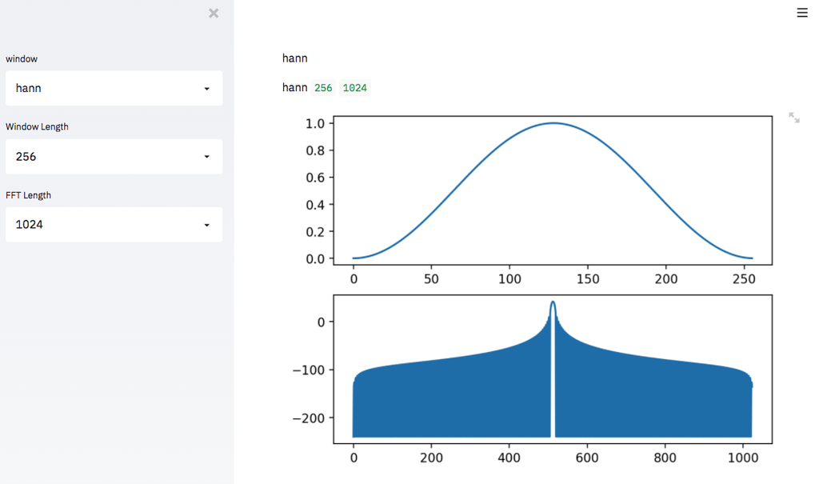

### `streamlit`の描画ライブラリ

- `st.line_chart`, `st.area_chart`, `st.bar_chart`
  - `st.altair_chart`のsyntax sugar
  - 手軽に使える反面細かい設定は不可能
- その他`vega`, `plotly`, `bokeh`なども使用可能

```python
%%writefile -a app.py
st.line_chart(win)
st.line_chart(W)
```

```
Appending to app.py
```

- `st.line_chart`の見た目

[figure not shown]

### この時点でのファイルの内容

- 通常の実行スクリプトに近い
- 手軽にフロントエンドの作成が可能

```python
!cat app.py | pygmentize
```

```
import streamlit as st

windows = ["boxcar", "triang", "blackman", "hamming", "hann", "bartlett", "flattop",
           "parzen", "bohman", "blackmanharris", "nuttall", "barthann"]

win_name = st.sidebar.selectbox("window", windows, 4)
st.write(win_name)
two_powers = [2**i for i in range(16)]
Nx = st.sidebar.selectbox("Window Length", two_powers, 8)
nfft = st.sidebar.selectbox("FFT Length", two_powers, 10)

st.write(win_name, Nx, nfft)
import matplotlib.pyplot as plt
import numpy as np
import scipy.signal as sg
import scipy.fft as fft
eps = 1.e-12
win = sg.get_window(win_name, Nx)
W = 20.0 * np.log10(np.abs(fft.fft(win, nfft)) + eps)
W = fft.fftshift(W)
fig, axes = plt.subplots(2, 1)
axes[0].plot(win)
axes[1].plot(W)
st.pyplot(fig)
st.line_chart(win)
st.line_chart(W)
```

### 複数の窓関数を同時に描画したい

- `st.multiselect(ラベル名, 選択肢のリスト, デフォルト項目の要素のリスト)`
  - 複数の選択項目をリストで返す
  - 第三引数は選択肢中に存在する要素のリスト

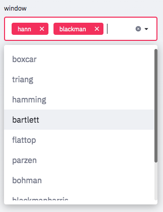

- 先程と同じ

```python
%%writefile app.py
import streamlit as st

windows = ["boxcar", "triang", "blackman", "hamming", "hann", "bartlett", "flattop",
           "parzen", "bohman", "blackmanharris", "nuttall", "barthann"]
```

```
Overwriting app.py
```

- 先程と同じ

```python
%%writefile -a app.py

import matplotlib.pyplot as plt
import numpy as np
import scipy.signal as sg
import scipy.fft as fft
```

```
Appending to app.py
```

- `st.multiselect`を使用

```python
%%writefile -a app.py

# ここから先が異なる
win_names = st.sidebar.multiselect("window", windows, [windows[4]])
st.write(win_names)
```

```
Appending to app.py
```

- `win_names`を`st.write`する以外は同じ

```python
%%writefile -a app.py
two_powers = [2**i for i in range(16)]
Nx = st.sidebar.selectbox("Window Length", two_powers, 8)
nfft = st.sidebar.selectbox("FFT Length", two_powers, 10)

st.write(win_names, Nx, nfft)
```

```
Appending to app.py
```

- `win_names`をループで処理

```python
%%writefile -a app.py
eps = 1.e-12
for win_name in win_names: # ループとして処理
    win = sg.get_window(win_name, Nx)
    W = 20.0 * np.log10(np.abs(fft.fft(win, nfft)) + eps)
    W = fft.fftshift(W)
```

```
Appending to app.py
```

```python
%%writefile -a app.py
    # ループの続き
    st.write(win_name)
    st.line_chart(win)
    st.line_chart(W)
```

```
Appending to app.py
```

- 複数の窓が繰り返し描画される

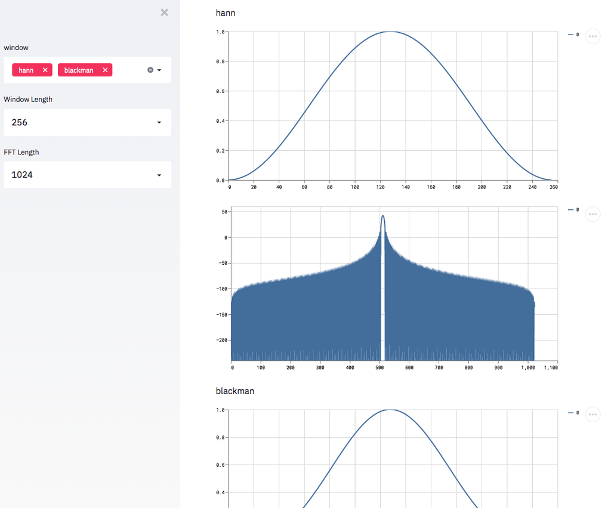

```python
!cat app.py | pygmentize
```

```
import streamlit as st

windows = ["boxcar", "triang", "blackman", "hamming", "hann", "bartlett", "flattop",
           "parzen", "bohman", "blackmanharris", "nuttall", "barthann"]

import matplotlib.pyplot as plt
import numpy as np
import scipy.signal as sg
import scipy.fft as fft

# ここから先が異なる
win_names = st.sidebar.multiselect("window", windows, [windows[4]])
st.write(win_names)
two_powers = [2**i for i in range(16)]
Nx = st.sidebar.selectbox("Window Length", two_powers, 8)
nfft = st.sidebar.selectbox("FFT Length", two_powers, 10)

st.write(win_names, Nx, nfft)
eps = 1.e-12
for win_name in win_names: # ループとして処理
    win = sg.get_window(win_name, Nx)
    W = 20.0 * np.log10(np.abs(fft.fft(win, nfft)) + eps)
    W = fft.fftshift(W)
    # ループの続き
    st.write(win_name)
    st.line_chart(win)
    st.line_chart(W)
```

### 複数の窓をまとめて描画したい

- pandasのDataFrameの複数カラムにデータを押し込む
- `st.line_chart`に渡す
- 先程と同じ

```python
%%writefile app.py
import streamlit as st

windows = ["boxcar", "triang", "blackman", "hamming", "hann", "bartlett", "flattop",
           "parzen", "bohman", "blackmanharris", "nuttall", "barthann"]
```

```
Overwriting app.py
```

- pandasを追加

```python
%%writefile -a app.py
import matplotlib.pyplot as plt
import numpy as np
import scipy.signal as sg
import scipy.fft as fft
import pandas as pd  # 追加
```

```
Appending to app.py
```

- 先程と同じ

```python
%%writefile -a app.py

win_names = st.sidebar.multiselect("window", windows, [windows[4]])
st.write(win_names)
```

```
Appending to app.py
```

- 先程と同じ

```python
%%writefile -a app.py
two_powers = [2**i for i in range(16)]
Nx = st.sidebar.selectbox("Window Length", two_powers, 8)
nfft = st.sidebar.selectbox("FFT Length", two_powers, 10)

st.write(win_names, Nx, nfft)
```

```
Appending to app.py
```

- 窓と周波数特性をlistに格納

```python
%%writefile -a app.py
eps = 1.e-12
win_ary = []; W_ary = []
for win_name in win_names: # ループとして処理
    win = sg.get_window(win_name, Nx)
    W = 20.0 * np.log10(np.abs(fft.fft(win, nfft)) + eps)
    W = fft.fftshift(W)
    win_ary.append(win)
    W_ary.append(W)
```

```
Appending to app.py
```

- DataFrameに格納

```python
%%writefile -a app.py
fs = 16000.0
t = np.arange(Nx)
f = (fs / nfft) * np.arange(-nfft/2, nfft/2)

df_win = pd.DataFrame(np.array(win_ary).T, index=t, columns=win_names)
df_W   = pd.DataFrame(np.array(W_ary).T,   index=f, columns=win_names)
```

```
Appending to app.py
```

```python
%%writefile -a app.py
st.line_chart(df_win)
st.line_chart(df_W)
```

```
Appending to app.py
```

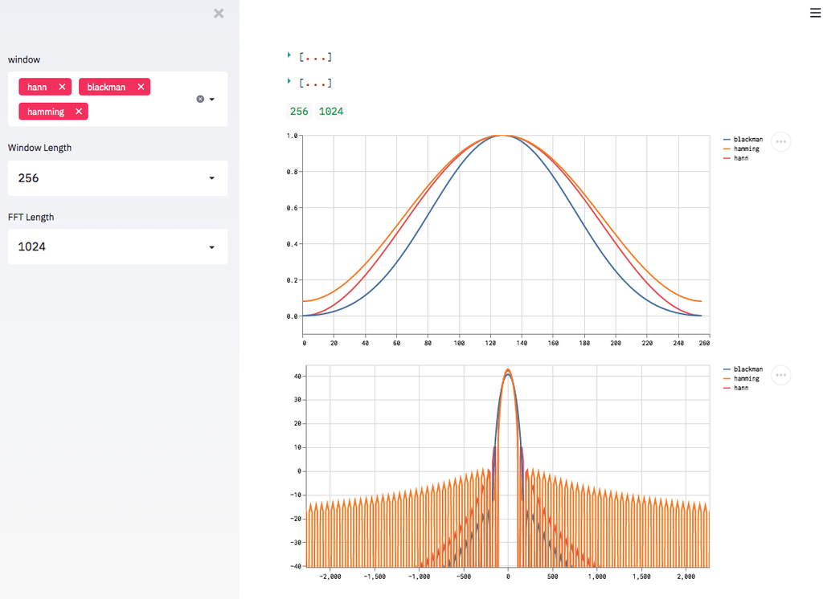

```python
!cat app.py | pygmentize
```

```
import streamlit as st

windows = ["boxcar", "triang", "blackman", "hamming", "hann", "bartlett", "flattop",
           "parzen", "bohman", "blackmanharris", "nuttall", "barthann"]
import matplotlib.pyplot as plt
import numpy as np
import scipy.signal as sg
import scipy.fft as fft
import pandas as pd  # 追加

win_names = st.sidebar.multiselect("window", windows, [windows[4]])
st.write(win_names)
two_powers = [2**i for i in range(16)]
Nx = st.sidebar.selectbox("Window Length", two_powers, 8)
nfft = st.sidebar.selectbox("FFT Length", two_powers, 10)

st.write(win_names, Nx, nfft)
eps = 1.e-12
win_ary = []; W_ary = []
for win_name in win_names: # ループとして処理
    win = sg.get_window(win_name, Nx)
    W = 20.0 * np.log10(np.abs(fft.fft(win, nfft)) + eps)
    W = fft.fftshift(W)
    win_ary.append(win)
    W_ary.append(W)
fs = 16000.0
t = np.arange(Nx)
f = (fs / nfft) * np.arange(-nfft/2, nfft/2)

df_win = pd.DataFrame(np.array(win_ary).T, index=t, columns=win_names)
df_W   = pd.DataFrame(np.array(W_ary).T,   index=f, columns=win_names)
st.line_chart(df_win)
st.line_chart(df_W)
```

## 窓関数ビューワのまとめ

- `st.selectbox`, `st.multiselect`を紹介
- `st.pyplot`, `st.line_chart`の使い方を紹介

## デジタルフィルタデザイナー

- `scipy.signal`のデジタルフィルタ設計関数を用いたダッシュボードを作成
  - 設計したフィルタをアップロードした音声に適用しブラウザ上で視聴
  - 処理後の音声のダウンロードリンクを生成

### 現状のダッシュボード

- filter_designer.py
  - `scipy.signal.firwin`のみ対応

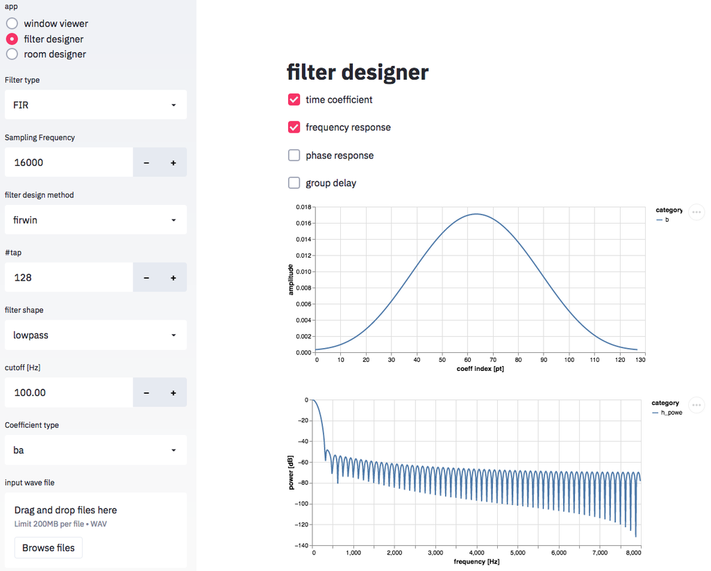

### 紹介する項目

- 数値入力
  - `st.number_input`
- チェックボックス
  - `st.checkbox`
- オーディオファイルのアップロード/ダウンロード
  - `st.file_uploader`
  - ダウンロードリンクは自力で作成
- オーディオファイルのブラウザ上での再生
  - `st.audio`

### 数値入力

- サンプリングレート、タップ長、カットオフ周波数の入力
- `st.number_input(ラベル名, min_value, max_value, value)`
  - valueなどの型はintからfloatで統一する必要有

```python
%%writefile app.py
import streamlit as st

fs = st.sidebar.number_input("Sampling Frequency", min_value=1,
                             max_value=192000, value=16000)
cutoff_hz = st.sidebar.number_input("cutoff [Hz]", min_value=0.0,
                                    max_value=fs/2.0, value=100.0)
```

```
Overwriting app.py
```

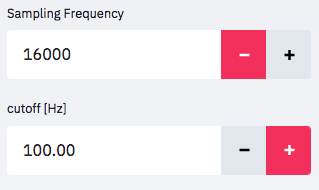

### チェックボックス

- `st.checkbox(ラベル名, デフォルト真偽値)`
  - チェックが入った場合のみ実行させる動作を記述可能

```python
%%writefile -a app.py

show_time_coeff = st.checkbox("time coefficient", value=True)
if show_time_coeff:
    pass  # do something
```

```
Appending to app.py
```

### オーディオファイルのアップロード

- `st.file_uploader(ラベル名, type)`
  - typeは拡張子、リストも可能
  - 返り値は`BytesIO`のサブクラス(`UploadedFile`)
    - file-like objectなのでファイルを要求する関数に渡せる

```python
%%writefile -a app.py

import soundfile as sf
wav_file = st.sidebar.file_uploader("input wave file", type="wav")
if wav_file is not None:
    sig, wav_fs = sf.read(wav_file)  # file-likeなので渡せる
    st.line_chart(sig)
```

```
Appending to app.py
```

- ファイルブラウザかドラッグアンドドロップでアップロード可能
  - Dockerコンテナ上だとエラーが発生(書き込み権限の問題?)

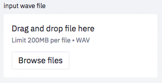

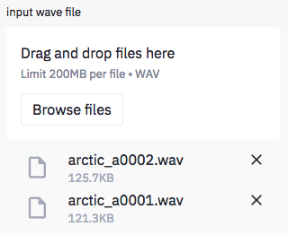

### オーディオファイルのブラウザ上での再生

- `st.audio(data)`
  - dataはファイル名、BytesIO、ndarrayなど
  - rawデータやndarrayの場合はファイルヘッダーが必要

```python
%%writefile -a app.py

if wav_file is not None:
    st.audio(wav_file)
```

```
Appending to app.py
```

### オーディオファイルの一括アップロード

- `st.file_uploader(ラベル名, type, encoding=None, accept_multiple_files=True)`
  - 最新版の`0.68.0`で導入
  - 返り値がリストになるため音声データのバッチ処理が可能
  - リロード時にうまく読み込めないバグがある?

```python
%%writefile -a app.py

wav_files = st.sidebar.file_uploader("input wave files", encoding=None,
                                     type="wav", accept_multiple_files=True)
if wav_files is not None:
    for wav_fname in wav_files:
        sig, wav_fs = sf.read(wav_fname)
        st.line_chart(sig)
```

```
Appending to app.py
```

### オーディオファイルのダウンロード

- 公式コンポーネントはまだない
- [workaround](https://discuss.streamlit.io/t/how-to-download-file-in-streamlit/1806/26)が存在
  - バイナリファイルをbase64エンコード
  - aタグを生成し`st.markdown`で表示
- ダウンロードリンクを作成するための関数

```python
%%writefile -a app.py

import os
import base64
def get_binary_file_downloader_html(bin_file, file_label='File', extension=""):
    with open(bin_file, 'rb') as f:
        data = f.read()
    bin_str = base64.b64encode(data).decode()
    href = f'<a href="data:application/octet-stream;base64,{bin_str}" download="{os.path.basename(bin_file)}{extension}">Download {file_label}</a>'
    return href
```

```
Appending to app.py
```

- 入力ファイルを0.5倍した波形を一時ファイルに保存の上でダウンロードリンクを作成

```python
%%writefile -a app.py

import tempfile
if wav_file is not None:
    sig, wav_fs = sf.read(wav_file)
    hsig = 0.5 * sig

    # 名前付き一時ファイルに保存
    fp = tempfile.NamedTemporaryFile()
    sf.write(fp.name, hsig, wav_fs, format="wav")
    st.audio(fp.name)

    # ダウンロードリンクを表示
    href = get_binary_file_downloader_html(fp.name, "filtered wave file", ".wav")
    st.markdown(href, unsafe_allow_html=True)
```

```
Appending to app.py
```

- 最終的なファイル
  - aタグにclassが自動挿入されているため注意

```python
!cat app.py | pygmentize
```

```
import streamlit as st

fs = st.sidebar.number_input("Sampling Frequency", min_value=1,
                             max_value=192000, value=16000)
cutoff_hz = st.sidebar.number_input("cutoff [Hz]", min_value=0.0,
                                    max_value=fs/2.0, value=100.0)

show_time_coeff = st.checkbox("time coefficient", value=True)
if show_time_coeff:
    pass  # do something

import soundfile as sf
wav_file = st.sidebar.file_uploader("input wave file", type="wav")
if wav_file is not None:
    sig, wav_fs = sf.read(wav_file)  # file-likeなので渡せる
    st.line_chart(sig)

if wav_file is not None:
    st.audio(wav_file)

wav_files = st.sidebar.file_uploader("input wave files", encoding=None,
                                     type="wav", accept_multiple_files=True)
if wav_files is not None:
    for wav_fname in wav_files:
        sig, wav_fs = sf.read(wav_fname)
        st.line_chart(sig)

import os
import base64
def get_binary_file_downloader_html(bin_file, file_label='File', extension=""):
    with open(bin_file, 'rb') as f:
        data = f.read()
    bin_str = base64.b64encode(data).decode()
    href = f'<a href="data:application/octet-stream;base64,{bin_str}" download="{os.path.basename(bin_file)}{extension}">Download {file_label}</a>'
    return href

import tempfile
if wav_file is not None:
    sig, wav_fs = sf.read(wav_file)
    hsig = 0.5 * sig

    # 名前付き一時ファイルに保存
    fp = tempfile.NamedTemporaryFile()
    sf.write(fp.name, hsig, wav_fs, format="wav")
    st.audio(fp.name)

    # ダウンロードリンクを表示
    href = get_binary_file_downloader_html(fp.name, "filtered wave file", ".wav")
    st.markdown(href, unsafe_allow_html=True)
```

### フィルタデザイナーのまとめ

- 数値入力とチェックボックスコンポーネントを紹介
- オーディオファイルのアップロード、再生、ダウンロード方法

## `pyroomacoustics`を用いたシミュレータ

- `pyroomacoustics`のroomオブジェクト、音源、マイクをGUIで配置
- RIR生成または伝搬シミュレーションを実行

### 現状のダッシュボード

- room_designer.py
  - `Shoebox`のみ対応

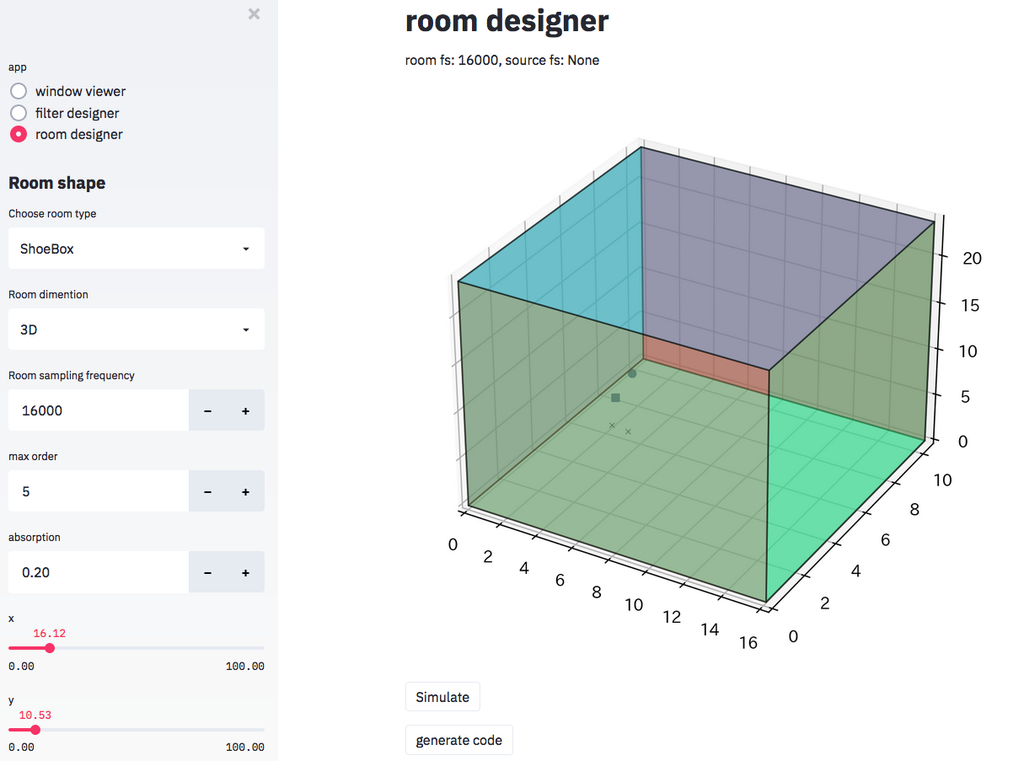

### 紹介する内容

- スライダー
  - `st.slider`
- ボタン
  - `st.button`

### スライダー

- `st.slider(ラベル名, min_value, max_value, value)`
  - valueの類は省略可能

```
rx = st.sidebar.slider("x", min_value=0.0, max_value=100.0)
```

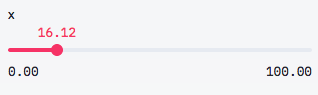

### ボタン

- `st.button(ラベル名)`

```
ret = st.button("Simulate")
    if ret:
        pass
```

## アプリケーションのタブ化

- *現在タブ用コンポーネントはない*
- `st.radio`で代用可能
  - ただしダッシュボードを切り替えると状態がリセットされる

### `st.radio`をタブ代わりに使用

- app.py

```
ret = st.sidebar.radio("app", ["window viewer", "filter designer", "room designer"])
print(ret)

if ret == "window viewer":
    window_viewer.main()
elif ret == "filter designer":
    filter_designer.main()
elif ret == "room designer":
    room_designer.main()
```

## espnet2のフロントエンド

- `espnet2`
  - pythonのみで処理可能
  - pre-trainedモデルをダウンロードする仕組みが存在
  - https://github.com/espnet/espnet_model_zoo
- ダッシュボード
  - espnet2_loader.py
  - asrのみ対応

### モデルのダウンロード

- `table.csv`記載のnameを打ち込むとモデルをダウンロード
  - 問題点:標準出力がキャプチャできないためダウンロード進捗が不明

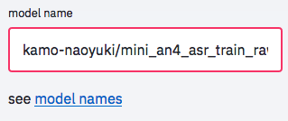

### 音声ファイルをアップロードすると自動的にデコード

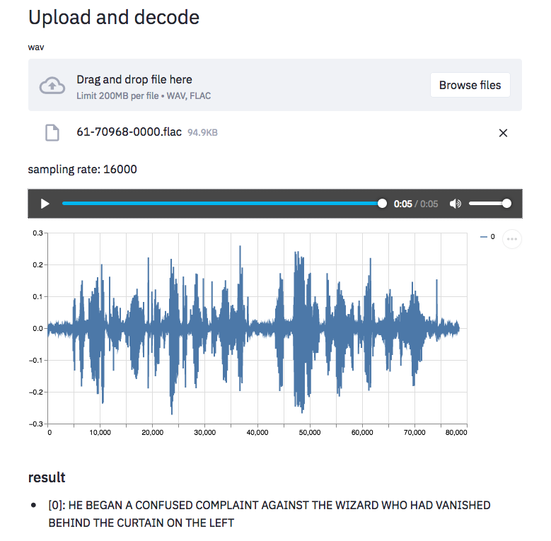

### モデルの情報を表示

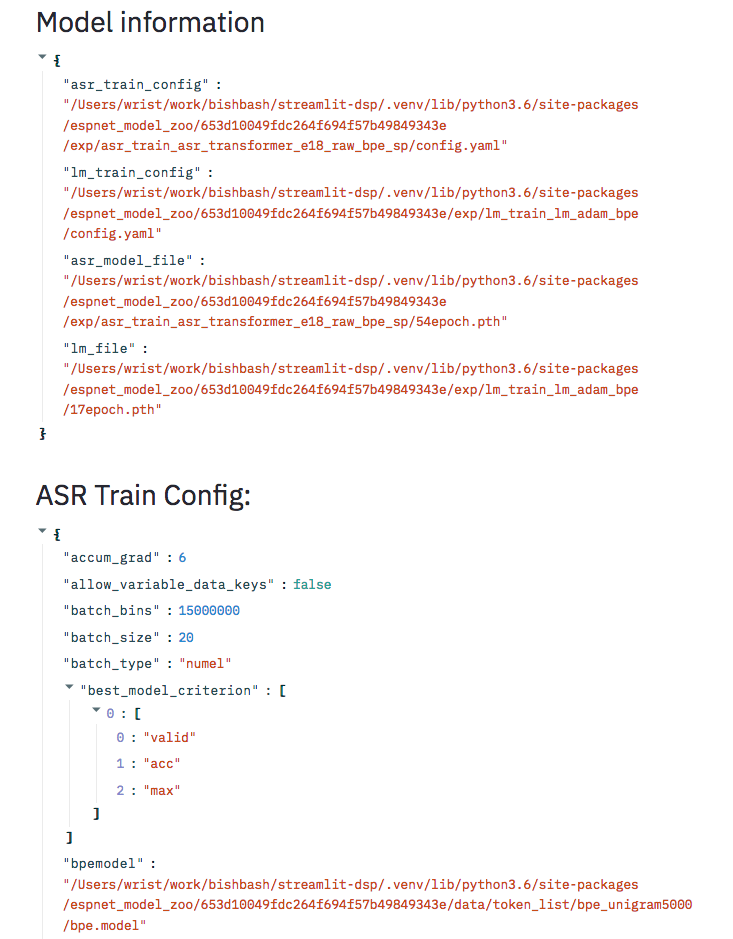

## Herokuへのデプロイ

- 実行環境として手軽に利用可能
  - `git push heroku local_branch:main`
- 実際に稼働中
  - https://streamlit-dsp.herokuapp.com

### 必要となるファイル

- `Procfile`
- `Aptfile`
- `requirements.txt`
- `runtime.txt`

### `Procfile`

- 実行時のコマンドを記述
- 内容: `web: streamlit run --server.enableCORS false --server.port $PORT streamlit_dsp/app.py`

### `runtime.txt`

- ランタイムバージョンを指定する場合に必要
- [使用可能なランタイム](https://devcenter.heroku.com/articles/python-support#supported-runtimes)
- 内容: `Python 3.8.6`

### `Aptfile`

- `apt install`する対象を記述
  - `soundfile`ライブラリが`libsndfile`に依存
- buildpackが必要
  - `heroku buildpacks:add heroku-community/apt`
- 内容: `libsndfile-dev`

### `requirements.txt`

- 依存ライブラリを記述
- HerokuはPoetryに対応していない
  - python-poetry-buildpack
    - `pyproject.toml`からpush時に動的に`requirements.txt`を生成
    - しかしエラー時に対処できないのでローカルで予め生成しておく
  - `poetry export -f requirements.txt --output requirements.txt`

### 最終的な実行コマンド

- 必要なファイルが揃った上で下記を実行

```
$ heroku buildpacks:clear
$ heroku buildpacks:add heroku-community/apt
$ heroku buildpacks:add heroku/python
$ heroku create
$ git push heroku heroku:main
$ heroku open
```

## その他の話題

### ASTの書き換えによるコード生成

- ほぼスクリプトライクに書けるため代入の上書きにより通常のスクリプトとして実行できるようにすることも可能
- 標準ライブラリ`ast`でコードを書き換え`astor`ライブラリでコードを生成
- そのまま実行できるものが出来上がるわけではないが取っ掛かりに便利

### `st.cache`によるキャッシュ機構

- 時間のかかる計算や大きなモデルのダウンロードに対してキャッシュ動作を実現
- [ドキュメント](https://docs.streamlit.io/en/stable/caching.html)
  - キャッシュ機能を付与したい関数に`@st.cache`というデコレータを付与
  - 引数、返り値、本体内部の変化を監視

### まだ足りないと感じる要素(1)

- タブ
- デフォルトの可視化コンポーネント
  - 軸ラベルぐらい指定したい
- 複雑なレイアウト
  - [ベータ機能としてコンテナなどが追加](https://docs.streamlit.io/en/stable/api.html#lay-out-your-app)

### まだ足りないと感じる要素(2)

- 編集可能なテーブル
  - フィルタ係数を入力して可視化することなどが困難
- ユーザー認証および状態の永続化
  - `SessionState.py`を使う例
  - https://discuss.streamlit.io/t/alternative-implementation-of-session-state/799

### また足りないと感じる要素(3)

- 標準出力のキャプチャ
  - 処理進捗を標準出力に出すコマンドで困る
  - https://github.com/streamlit/streamlit/issues/268
    - `contextlib`でredirectは可能だが、非同期実行ができない
- 仕様の安定性
  - 複数ファイルアップローダにおいて再読み込み時にエラーが発生

### コンポーネントの自作

- 必要なコンポーネントは自作することが可能とのこと
- https://docs.streamlit.io/en/stable/publish_streamlit_components.html

## まとめ

- 自作のダッシュボードを通じて`Streamlit`について紹介
- デプロイ方法およびその他の話題を紹介